# Homework 12

Joe Dickerson

2025-04-23

```r
library(tidyverse)
library(faraway)
library(lme4)
library(MASS)
library(geepack)
data(ohio)
```

*resp* an indicator of wheeze status (1 = yes, 0 = no) *id* an identifier for the child *age* 7 yrs = −2, 8 yrs = −1, 9 yrs = 0, 10 yrs = 1 *smoke* an indicator of maternal smoking at the first year of the study (1 = smoker, 0 = nonsmoker)

1. Do any of the mothers in the study change their smoking status during the period of observation?

*I am using a late homework assignment token on this submission*

No mothers change their smoking status throughout the period of observation. We check this with logic and using tools from the dplyr package.

```r
ohio %>%
  group_by(id) %>%
  summarize(smoke_min = min(smoke),
            smoke_max = max(smoke),
            .groups = "drop") %>%
  filter(smoke_min != smoke_max)
```

```
## # A tibble: 0 × 3
## # ℹ 3 variables: id <int>, smoke_min <int>, smoke_max <int>
```

2. Construct a table that shows proportion of children who wheeze for 0, 1, 2, 3 or 4 years broken down by maternal smoking status.

```r
subject_quantity <- length(unique(ohio$id))

xtabs(resp ~ age + smoke, ohio)/subject_quantity
```

```
##     smoke
## age           0          1
##   -2 0.10428305 0.05772812
##   -1 0.09683426 0.07262570
##   0  0.09310987 0.06517691
##   1  0.06890130 0.04841713
```

3. Make plot which shows how the proportion of children wheezing changes by age with a separate line for smoking and nonsmoking mothers.

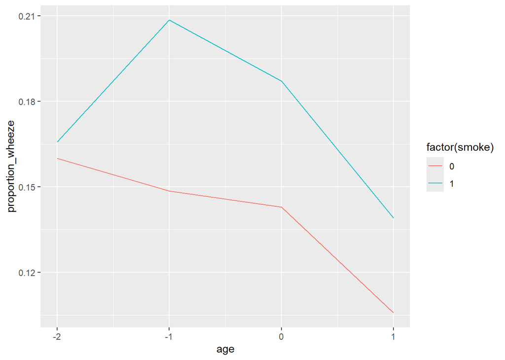

```r
gg <- ohio %>%
  group_by(age, smoke) %>%
  summarize(proportion_wheeze = mean(resp), .groups = "drop")

gg %>%
  ggplot(aes(x = age, y = proportion_wheeze, color = factor(smoke))) +
  geom_line()
```

4. Group the data by child to count the total (out of four) years of wheezing. Fit a binomial GLM to this response to check for a maternal smoking effect. Does this prove there is a smoking effect or could there be another plausible explanation?

Though maternal smoking is significant, I do not think that it “proves” a smoking effect, though it does seem to suggest one. There could be a more plausible explanation, though it would take further analysis to uncover.

```r
glm_data <- ohio %>%
  group_by(id) %>%
  summarize(
    wheeze_years = sum(resp),
    total_yrs = n(),
    smoke = first(smoke)
  )

glm <- glm(cbind(wheeze_years, total_yrs - wheeze_years) ~ smoke, family = binomial, glm_data)

summary(glm)
```

```
##
## Call:
## glm(formula = cbind(wheeze_years, total_yrs - wheeze_years) ~
##     smoke, family = binomial, data = glm_data)
##
## Coefficients:
##             Estimate Std. Error z value Pr(>|z|)
## (Intercept) -1.82124    0.07719 -23.595   <2e-16 ***
## smoke        0.27156    0.12334   2.202   0.0277 *
## ---
## Signif. codes:  0 '***' 0.001 '**' 0.01 '*' 0.05 '.' 0.1 ' ' 1
##
## (Dispersion parameter for binomial family taken to be 1)
##
##     Null deviance: 1045.3  on 536  degrees of freedom
## Residual deviance: 1040.5  on 535  degrees of freedom
## AIC: 1337.9
##
## Number of Fisher Scoring iterations: 4
```

5. Fit a model for each individual response using a GLMM fit using penalized quasi-likelihood. Describe the effects of age and maternal smoking. How do the odds of wheezing change numerically over time?

```r
modpql <- glmmPQL(resp ~ smoke + age + I(smoke*age), random = ~1|id, family=binomial, ohio )
```

```
## iteration 1
```

```
## iteration 2
```

```
## iteration 3
```

```
## iteration 4
```

```
## iteration 5
```

```
## iteration 6
```

```
## iteration 7
```

```
## iteration 8
```

```r
summary(modpql)
```

```
## Linear mixed-effects model fit by maximum likelihood
##   Data: ohio
##   AIC BIC logLik
##    NA  NA     NA
##
## Random effects:
##  Formula: ~1 | id
##         (Intercept)  Residual
## StdDev:    2.058848 0.6352806
##
## Variance function:
##  Structure: fixed weights
##  Formula: ~invwt
## Fixed effects:  resp ~ smoke + age + I(smoke * age)
##                     Value  Std.Error   DF    t-value p-value
## (Intercept)    -2.7946368 0.14450555 1609 -19.339305  0.0000
## smoke           0.3932561 0.23805479  535   1.651956  0.0991
## age            -0.2237722 0.05588650 1609  -4.004048  0.0001
## I(smoke * age)  0.1089708 0.08961638 1609   1.215970  0.2242
##  Correlation:
##                (Intr) smoke  age
## smoke          -0.607
## age             0.261 -0.158
## I(smoke * age) -0.163  0.232 -0.624
##
## Standardized Within-Group Residuals:
##        Min         Q1        Med         Q3        Max
## -2.6611967 -0.2906814 -0.2599021 -0.2077762  3.5669784
##
## Number of Observations: 2148
## Number of Groups: 537
```

```r
first(exp(coef(modpql)))
```

```
##   (Intercept)    smoke       age I(smoke * age)
## 1  0.02182198 1.481798 0.7994972        1.11513
```

6. Now fit the same model but using adaptive Gaussian-Hermit quadrature. Compare to the previous model fit.

We see a similar fit as part e. An insignificant interaction between smoke and age. Our coefficient for the interaction is 0.1053, which exponentiated is 1.11, a very similar outcome to the odds from the previous problem.

```r
modgh <- glmer(resp ~ smoke + age + I(smoke*age) + (1|id), nAGQ = 25, family = binomial, ohio)

summary(modgh)
```

```
## Generalized linear mixed model fit by maximum likelihood (Adaptive
##   Gauss-Hermite Quadrature, nAGQ = 25) [glmerMod]
##  Family: binomial  ( logit )
## Formula: resp ~ smoke + age + I(smoke * age) + (1 | id)
##    Data: ohio
##
##      AIC      BIC   logLik deviance df.resid
##   1604.7   1633.1   -797.4   1594.7     2143
##
## Scaled residuals:
##     Min      1Q  Median      3Q     Max
## -1.3660 -0.1988 -0.1784 -0.1437  2.5930
##
## Random effects:
##  Groups Name        Variance Std.Dev.
##  id     (Intercept) 4.694    2.167
## Number of obs: 2148, groups:  id, 537
##
## Fixed effects:
##                Estimate Std. Error z value Pr(>|z|)
## (Intercept)    -3.12840    0.22286 -14.038   <2e-16 ***
## smoke           0.46204    0.28557   1.618   0.1057
## age            -0.21637    0.08656  -2.500   0.0124 *
## I(smoke * age)  0.10533    0.13849   0.761   0.4469
## ---
## Signif. codes:  0 '***' 0.001 '**' 0.01 '*' 0.05 '.' 0.1 ' ' 1
##
## Correlation of Fixed Effects:
##             (Intr) smoke  age
## smoke       -0.517
## age          0.300 -0.199
## I(smok*age) -0.171  0.290 -0.623
```

```r
exp(0.1053)
```

```
## [1] 1.111044
```

1. Fit the model using GEE. Use an autoregressive rather than exchangeable error structure. Compare the results to the previous model fits. In your model, what indicates that a child who already wheezes is likely to continue to wheeze?

Once again, we have a similar result to the previous models. We see roughly the same significance and standard errors. The odds of wheezing with the interaction is now 1.09. Because the odds are so close to 1, it seems possible that regardless of maternal smoking, a child is as likely to continue to wheeze if they already have symptoms of wheezing.

```r
modgeep <- geeglm(resp ~ smoke + age + I(smoke*age), id=id, family = binomial, corstr = "ar1", ohio)

summary(modgeep)
```

```
##
## Call:
## geeglm(formula = resp ~ smoke + age + I(smoke * age), family = binomial,
##     data = ohio, id = id, corstr = "ar1")
##
##  Coefficients:
##                Estimate  Std.err    Wald Pr(>|W|)
## (Intercept)    -1.92477  0.12070 254.312   <2e-16 ***
## smoke           0.28877  0.19138   2.277   0.1313
## age            -0.14780  0.05984   6.101   0.0135 *
## I(smoke * age)  0.08355  0.09167   0.831   0.3621
## ---
## Signif. codes:  0 '***' 0.001 '**' 0.01 '*' 0.05 '.' 0.1 ' ' 1
##
## Correlation structure = ar1
## Estimated Scale Parameters:
##
##             Estimate Std.err
## (Intercept)    1.022  0.1254
##   Link = identity
##
## Estimated Correlation Parameters:
##       Estimate Std.err
## alpha   0.4914 0.06799
## Number of clusters:   537  Maximum cluster size: 4
```

```r
exp(0.0835)
```

```
## [1] 1.087
```

10. What is your overall conclusion regarding the effect of age and maternal smoking? Can we trust the GLM result or are the GLMM models preferable?